# Exploratory Data Analysis

SW

2025-01-31

[figure not shown]

Objectives

After completing this lab you will be able to:

- Explore features or characteristics to predict price of car
- Analyze patterns and run descriptive statistical analysis
- Group data based on identified parameters and create pivot tables
- Identify the effect of independent attributes on price of cars

## Table of Contents

1. Import Data
2. Analyzing Individual Feature Patterns using Visualization
3. Descriptive Statistical Analysis
4. Basics of Grouping
5. Correlation and Causation

# 1 Import Data

Import libraries:

```python
import pandas as pd
import numpy as np
```

Download the dataset and store it in dataframe `df`:

```python
filepath='https://cf-courses-data.s3.us.cloud-object-storage.appdomain.cloud/\
IBMDeveloperSkillsNetwork-DA0101EN-SkillsNetwork/labs/Data%20files/automobileEDA.csv'
df = pd.read_csv(filepath, header=0)
```

View the first 5 values of the dataframe using `datafame.head()`:

```python
df.head()
```

```
##    symboling  normalized-losses         make  ... horsepower-binned diesel gas
## 0          3                122  alfa-romero  ...            Medium      0   1
## 1          3                122  alfa-romero  ...            Medium      0   1
## 2          1                122  alfa-romero  ...            Medium      0   1
## 3          2                164         audi  ...            Medium      0   1
## 4          2                164         audi  ...            Medium      0   1
##
## [5 rows x 29 columns]
```

# 2 Analyzing Individual Feature Patterns Using Visualization

Import visualization packages “Matplotlib” and “Seaborn”. Don’t forget about “%matplotlib inline” to plot in a Jupyter notebook.

```python
import matplotlib.pyplot as plt
import seaborn as sns
```

```python
import prettytable
prettytable.DEFAULT = 'DEFAULT'
```

## 2.1 Data types

#### How to choose the right visualization method?

When visualizing individual variables, it is important to first understand what type of variable you are dealing with. This will help us find the right visualization method for that variable.

```python
# list the data types for each column
print(df.dtypes)
```

```
## symboling              int64
## normalized-losses      int64
## make                  object
## aspiration            object
## num-of-doors          object
## body-style            object
## drive-wheels          object
## engine-location       object
## wheel-base           float64
## length               float64
## width                float64
## height               float64
## curb-weight            int64
## engine-type           object
## num-of-cylinders      object
## engine-size            int64
## fuel-system           object
## bore                 float64
## stroke               float64
## compression-ratio    float64
## horsepower           float64
## peak-rpm             float64
## city-mpg               int64
## highway-mpg            int64
## price                float64
## city-L/100km         float64
## horsepower-binned     object
## diesel                 int64
## gas                    int64
## dtype: object
```

If we want to know the data type of a particular column, we can use the method `df['Column-Name'].dtypes`. For example, the data type of the column `peak-rpm` is given by:

```python
df['peak-rpm'].dtypes
```

```
## dtype('float64')
```

Further, we can calculate the correlation between variables of type “int64” or “float64” using the method “corr”:

```python
# select only numeric columns for correlation
numeric_df = df.select_dtypes(include=['float64', 'int64'])
numeric_df.corr()
```

```
##                    symboling  normalized-losses  ...    diesel       gas
## symboling           1.000000           0.466264  ... -0.196735  0.196735
## normalized-losses   0.466264           1.000000  ... -0.101546  0.101546
## wheel-base         -0.535987          -0.056661  ...  0.307237 -0.307237
## length             -0.365404           0.019424  ...  0.211187 -0.211187
## width              -0.242423           0.086802  ...  0.244356 -0.244356
## height             -0.550160          -0.373737  ...  0.281578 -0.281578
## curb-weight        -0.233118           0.099404  ...  0.221046 -0.221046
## engine-size        -0.110581           0.112360  ...  0.070779 -0.070779
## bore               -0.140019          -0.029862  ...  0.054458 -0.054458
## stroke             -0.008245           0.055563  ...  0.241303 -0.241303
## compression-ratio  -0.182196          -0.114713  ...  0.985231 -0.985231
## horsepower          0.075819           0.217299  ... -0.169053  0.169053
## peak-rpm            0.279740           0.239543  ... -0.475812  0.475812
## city-mpg           -0.035527          -0.225016  ...  0.265676 -0.265676
## highway-mpg         0.036233          -0.181877  ...  0.198690 -0.198690
## price              -0.082391           0.133999  ...  0.110326 -0.110326
## city-L/100km        0.066171           0.238567  ... -0.241282  0.241282
## diesel             -0.196735          -0.101546  ...  1.000000 -1.000000
## gas                 0.196735           0.101546  ... -1.000000  1.000000
##
## [19 rows x 19 columns]
```

The diagonal elements are always one.

We can also find the correlation between particular columns. For example, we can use the following code to find the correlation between the columns `bore`, `stroke`, `compression-ratio`, and `horsepower`.

```python
df[['bore', 'stroke', 'compression-ratio', 'horsepower']].corr()
```

```
##                        bore    stroke  compression-ratio  horsepower
## bore               1.000000 -0.055390           0.001263    0.566936
## stroke            -0.055390  1.000000           0.187923    0.098462
## compression-ratio  0.001263  0.187923           1.000000   -0.214514
## horsepower         0.566936  0.098462          -0.214514    1.000000
```

## 2.2 Continuous Numerical Variables

Continuous numerical variables are variables that may contain any value within some range. They can be of type `int64` or `float64`. A great way to visualize these variables is by using scatterplots with fitted lines.

In order to start understanding the (linear) relationship between an individual variable and the price, we can use `regplot` which plots the scatterplot plus the fitted regression line for the data. This will be useful later on for visualizing the fit of the simple linear regression model as well.

Let’s see several examples of different linear relationships:

### 2.2.1 Positive Linear Relationship

Let’s find the scatterplot of “engine-size” and “price”.

```
## (0.0, 53099.02573697669)
```

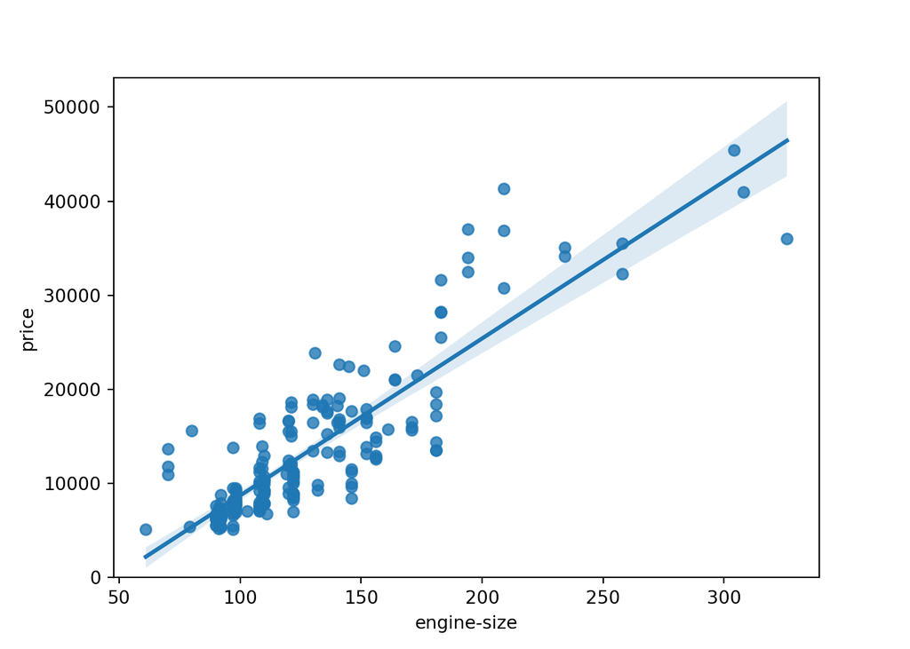

```python
# Engine size as potential predictor variable of price
sns.regplot(x="engine-size", y="price", data=df)
plt.ylim(0,)
```

As the engine-size goes up, the price goes up: this indicates a positive direct correlation between these two variables. Engine size seems like a pretty good predictor of price since the regression line is almost a perfect diagonal line.

We can examine the correlation between ‘engine-size’ and ‘price’ and see that it’s approximately 0.87.

```python
df[['engine-size','price']].corr()
```

```
##              engine-size     price
## engine-size     1.000000  0.872335
## price           0.872335  1.000000
```

### 2.2.2 Negative Linear Relationship

Highway mpg is a potential predictor variable of price. Let’s find the scatterplot of `highway-mpg` and `price`.

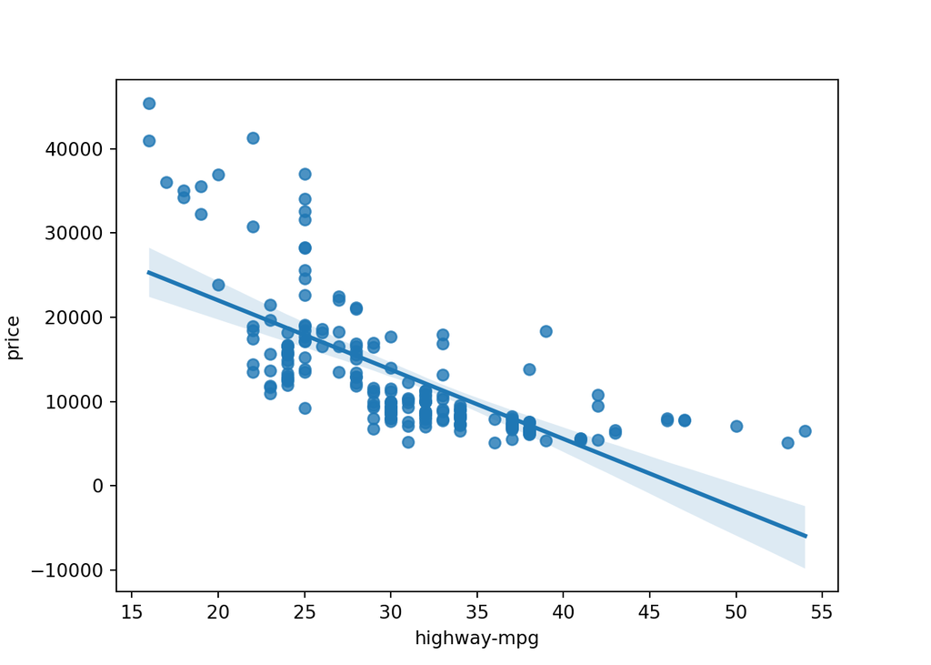

```python
sns.regplot(x='highway-mpg', y='price', data=df)
```

As `highway-mpg` goes up, the `price` goes down: this indicates an inverse/negative relationship between these two variables. Highway mpg could potentially be a predictor of price.

We can examine the correlation between `highway-mpg` and `price` and see it’s approximately -0.704.

```python
df[['highway-mpg', 'price']].corr()
```

```
##              highway-mpg     price
## highway-mpg     1.000000 -0.704692
## price          -0.704692  1.000000
```

### 2.2.3 Weak Linear Relationship

Let’s see if `peak-rpm` is a predictor variable of `price`.

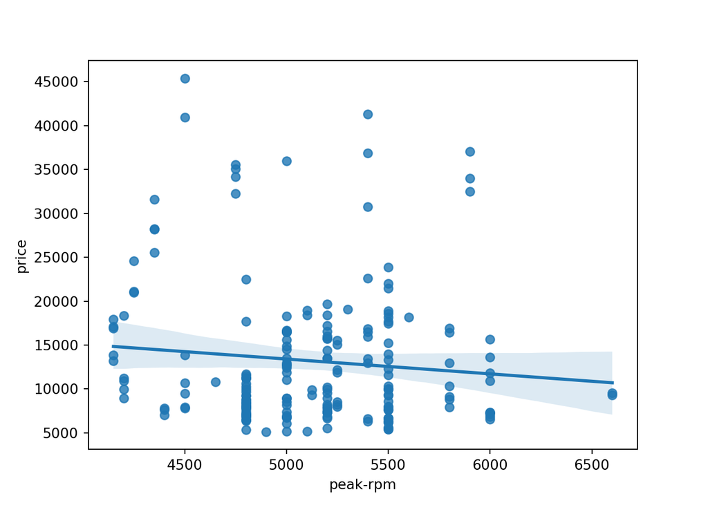

```python
sns.regplot(x='peak-rpm', y='price', data=df)
```

Peak rpm does not seem like a good predictor of the price at all since the regression line is close to horizontal. Also, the data points are very scattered and far from the fitted line, showing lots of variability. Therefore, it’s not a reliable variable.

We can examine the correlation between ‘peak-rpm’ and ‘price’ and see it’s approximately -0.101616.

```python
df[['peak-rpm','price']].corr()
```

```
##           peak-rpm     price
## peak-rpm  1.000000 -0.101616
## price    -0.101616  1.000000
```

## 2.3 Categorical Variables

These are variables that describe a ‘characteristic’ of a data unit, and are selected from a small group of categories. The categorical variables can have the type `object` or `int64`. A good way to visualize categorical variables is by using boxplots.

Let’s look at the relationship between `body-style` and `price`.

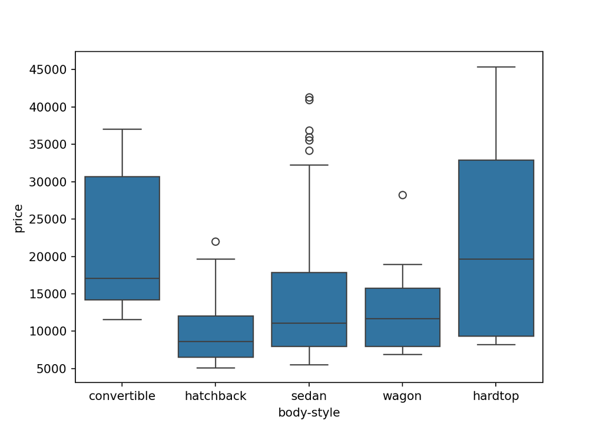

```python
sns.boxplot(x="body-style", y="price", data=df)
```

We see that the distributions of price between the different body-style categories have a significant overlap, so body-style would not be a good predictor of price. Let’s examine engine `engine-location` and `price`:

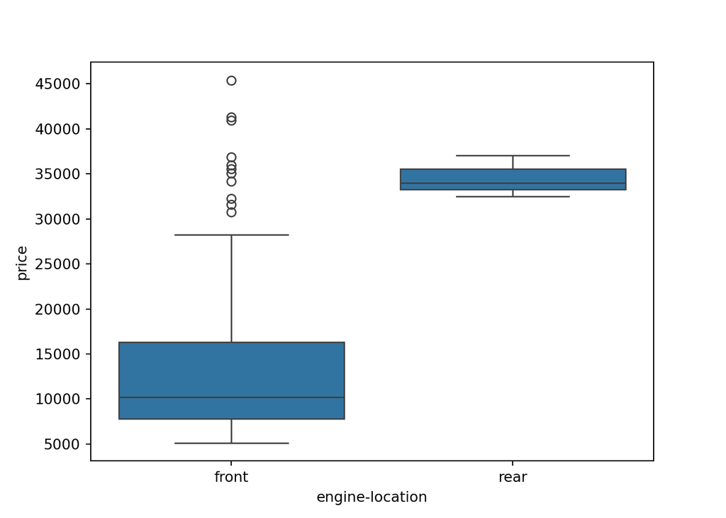

```python
sns.boxplot(x='engine-location', y='price', data=df)
```

Here we see that the distribution of price between these two engine-location categories, front and rear, are distinct enough to take engine-location as a potential good predictor of price.

Let’s examine `drive-wheels` and `price`.

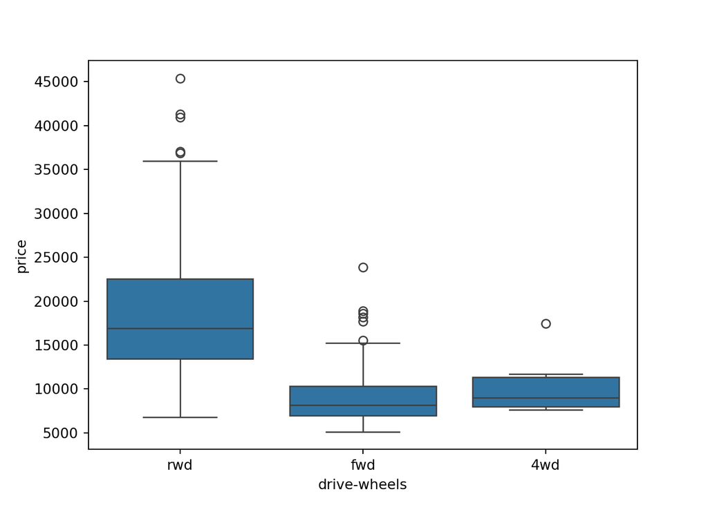

```python
sns.boxplot(x='drive-wheels', y='price', data=df)
```

Here we see that the distribution of price between the different drive-wheels categories differs. As such, drive-wheels could potentially be a predictor of price.

# 3 Descriptive Statistical Analysis

## 3.1 **describe** method

Let’s first take a look at the variables by utilizing a description method.

The **describe** function automatically computes basic statistics for all continuous variables. Any NaN values are automatically skipped in these statistics.

This will show:

- the count of that variable
- the mean
- the standard deviation (std)
- the minimum value
- the IQR (Interquartile Range: 25%, 50% and 75%)
- the maximum value

We can apply the method **describe** as follows:

```python
df.describe()
```

```
##         symboling  normalized-losses  ...      diesel         gas
## count  201.000000          201.00000  ...  201.000000  201.000000
## mean     0.840796          122.00000  ...    0.099502    0.900498
## std      1.254802           31.99625  ...    0.300083    0.300083
## min     -2.000000           65.00000  ...    0.000000    0.000000
## 25%      0.000000          101.00000  ...    0.000000    1.000000
## 50%      1.000000          122.00000  ...    0.000000    1.000000
## 75%      2.000000          137.00000  ...    0.000000    1.000000
## max      3.000000          256.00000  ...    1.000000    1.000000
##
## [8 rows x 19 columns]
```

The default setting of **describe** skips variables of type `object`. We can apply the method **describe** on the variables of type `object` as follows:

```python
df.describe(include=['object'])
```

```
##           make aspiration  ... fuel-system horsepower-binned
## count      201        201  ...         201               200
## unique      22          2  ...           8                 3
## top     toyota        std  ...        mpfi               Low
## freq        32        165  ...          92               115
##
## [4 rows x 10 columns]
```

We can also use the following code to find the basic statistics of some particular columns:

```python
df[['peak-rpm','price']].describe()
```

```
##           peak-rpm         price
## count   201.000000    201.000000
## mean   5117.665368  13207.129353
## std     478.113805   7947.066342
## min    4150.000000   5118.000000
## 25%    4800.000000   7775.000000
## 50%    5125.369458  10295.000000
## 75%    5500.000000  16500.000000
## max    6600.000000  45400.000000
```

## 3.2 **value_counts** method

Value counts is a good way of understanding how many units of each characteristic/variable we have. We can apply the `value_counts` method on the column “drive-wheels”. Don’t forget the method `value_counts` only works on pandas series, not pandas dataframes. As a result, we only include one bracket `df[‘drive-wheels’]`, not two brackets `df[[‘drive-wheels’]]`.

```python
df['drive-wheels'].value_counts()
```

```
## drive-wheels
## fwd    118
## rwd     75
## 4wd      8
## Name: count, dtype: int64
```

We can convert the series to a dataframe as follows:

```python
df['drive-wheels'].value_counts().to_frame()
```

```
##               count
## drive-wheels
## fwd             118
## rwd              75
## 4wd               8
```

Let’s repeat the above steps but save the results to the dataframe `drive_wheels_counts` and rename the column `drive-wheels` to `value_counts`.

```python
drive_wheels_counts = df['drive-wheels'].value_counts().to_frame()
drive_wheels_counts.reset_index(inplace=True)
drive_wheels_counts = drive_wheels_counts.rename(columns={'drive-wheels':'value_counts'})
drive_wheels_counts
```

```
##   value_counts  count
## 0          fwd    118
## 1          rwd     75
## 2          4wd      8
```

Now let’s rename the index to ‘drive-wheels’:

```python
drive_wheels_counts.index.name = 'drive-wheels'
drive_wheels_counts
```

```
##              value_counts  count
## drive-wheels
## 0                     fwd    118
## 1                     rwd     75
## 2                     4wd      8
```

We can repeat the above process for the variable ‘engine-location’.

```python
# engine-location as variable
engine_loc_counts = df['engine-location'].value_counts().to_frame()
engine_loc_counts.rename(columns={'engine-location': 'value_counts'}, inplace=True)
engine_loc_counts.index.name = 'engine-location'
engine_loc_counts
```

```
##                  count
## engine-location
## front              198
## rear                 3
```

After examining the value counts of the engine location, we see that engine location would not be a good predictor variable for the price. This is because we only have three cars with a rear engine and 198 with an engine in the front, so this result is skewed. Thus, we are not able to draw any conclusions about the engine location.

# 4 Basics of Grouping

## 4.1 **groupby** method

The **groupby** method groups data by different categories. The data is grouped based on one or several variables, and analysis is performed on the individual groups.

For example, let’s group by the variable `drive-wheels`. We see that there are 3 different categories of drive wheels.

```python
df['drive-wheels'].unique()
```

```
## array(['rwd', 'fwd', '4wd'], dtype=object)
```

If we want to know, on average, which type of drive wheel is most valuable, we can group `drive-wheels` and then average them.

We can select the columns `drive-wheels`, `body-style` and `price`, then assign it to the variable `df_group_one`.

```python
df_group_one = df[['drive-wheels', 'body-style', 'price']]
```

We can then calculate the average price for each of the different categories of data.

```python
# group by one variable
df_grouped = df_group_one.groupby(['drive-wheels'], as_index=False).agg({'price': 'mean'})
df_grouped
```

```
##   drive-wheels         price
## 0          4wd  10241.000000
## 1          fwd   9244.779661
## 2          rwd  19757.613333
```

From our data, it seems rear-wheel drive vehicles are, on average, the most expensive, while 4-wheel and front-wheel are approximately the same in price.

You can also group by multiple variables. For example, let’s group by both `drive-wheels` and `body-style`. This groups the dataframe by the unique combination of ‘drive-wheels’ and ‘body-style’. We can store the results in the variable `grouped_test1`.

```python
# group by multiple variables
grouped_test1 = df_group_one.groupby(['drive-wheels','body-style'], as_index=False).mean()
grouped_test1
```

```
##    drive-wheels   body-style         price
## 0           4wd    hatchback   7603.000000
## 1           4wd        sedan  12647.333333
## 2           4wd        wagon   9095.750000
## 3           fwd  convertible  11595.000000
## 4           fwd      hardtop   8249.000000
## 5           fwd    hatchback   8396.387755
## 6           fwd        sedan   9811.800000
## 7           fwd        wagon   9997.333333
## 8           rwd  convertible  23949.600000
## 9           rwd      hardtop  24202.714286
## 10          rwd    hatchback  14337.777778
## 11          rwd        sedan  21711.833333
## 12          rwd        wagon  16994.222222
```

## 4.2 **pivot** method

This grouped data is much easier to visualize when it is made into a pivot table. A pivot table is like an Excel spreadsheet, with one variable along the column and another along the row. We can convert the dataframe to a pivot table using the method **pivot** to create a pivot table from the groups.

In this case, we will leave the `drive-wheels` variable as the rows of the table, and pivot `body-style` to become the columns of the table:

```python
# create a pivot table
grouped_pivot = grouped_test1.pivot(index='drive-wheels', columns='body-style')
grouped_pivot
```

```
##                    price                ...
## body-style   convertible       hardtop  ...         sedan         wagon
## drive-wheels                            ...
## 4wd                  NaN           NaN  ...  12647.333333   9095.750000
## fwd              11595.0   8249.000000  ...   9811.800000   9997.333333
## rwd              23949.6  24202.714286  ...  21711.833333  16994.222222
##
## [3 rows x 5 columns]
```

Often, we won’t have data for some of the pivot cells. We can fill these missing cells with the value 0, but any other value could potentially be used as well. It should be mentioned that missing data is quite a complex subject and is an entire course on its own.

```python
# fill missing data with the value 0
grouped_pivot = grouped_pivot.fillna(0)
grouped_pivot
```

```
##                    price                ...
## body-style   convertible       hardtop  ...         sedan         wagon
## drive-wheels                            ...
## 4wd                  0.0      0.000000  ...  12647.333333   9095.750000
## fwd              11595.0   8249.000000  ...   9811.800000   9997.333333
## rwd              23949.6  24202.714286  ...  21711.833333  16994.222222
##
## [3 rows x 5 columns]
```

**Further Example**

Use the **groupby** method to find the average ‘price’ of each car based on ‘body-style’.

```python
grouped_test_bodystyle = df_group_one.groupby(['body-style'], as_index=False).agg({'price': 'mean'})
grouped_test_bodystyle
```

```
##     body-style         price
## 0  convertible  21890.500000
## 1      hardtop  22208.500000
## 2    hatchback   9957.441176
## 3        sedan  14459.755319
## 4        wagon  12371.960000
```

Alternatively, we can specify a new dataframe for just two variables `body-style` and `price` and then just use the **mean** method as follows:

```python
# alternative code
# this code chunk was not executed
df_gptest2 = df[['body-style','price']]
grouped_test_bodystyle = df_gptest2.groupby(['body-style'],as_index= False).mean()
grouped_test_bodystyle
```

## 4.3 Heat map

We will use the `pyplot` function in `matplotlib` to create a heat map to visualize the relationship between Body Style, Drive wheel and the Price.

```
## <function make_python_function.<locals>.python_function at 0x000002335816F560>
```

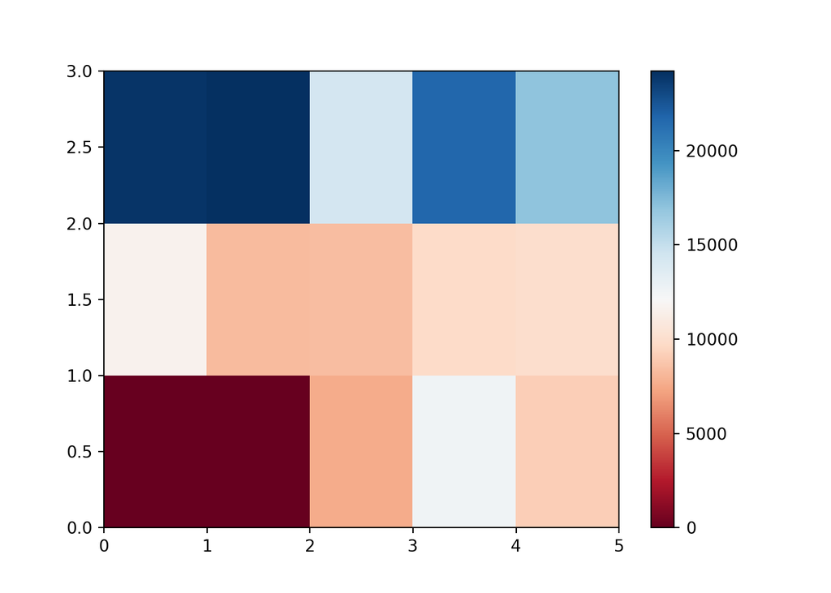

```python
# use the grouped results
plt.pcolor(grouped_pivot, cmap='RdBu')
plt.colorbar()
plt.show
```

The heatmap plots the target variable (price) proportional to colour with respect to the variables ‘drive-wheel’ and ‘body-style’ on the vertical and horizontal axis, respectively. This allows us to visualize how the price is related to ‘drive-wheel’ and ‘body-style’.

The default labels convey no useful information to us. Let’s change that:

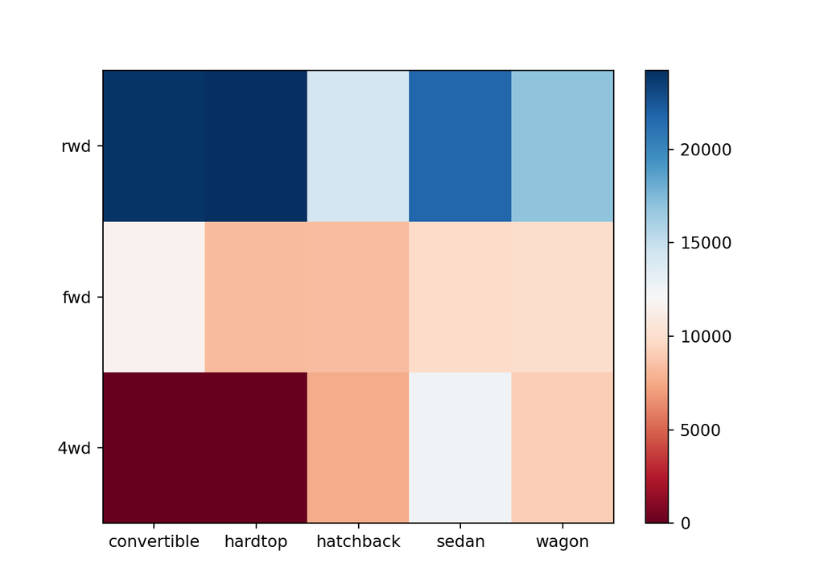

```python
fig, ax = plt.subplots()
im = ax.pcolor(grouped_pivot, cmap='RdBu')

#label names
row_labels = grouped_pivot.columns.levels[1]
col_labels = grouped_pivot.index

#move ticks and labels to the center
ax.set_xticks(np.arange(grouped_pivot.shape[1]) + 0.5, minor=False)
ax.set_yticks(np.arange(grouped_pivot.shape[0]) + 0.5, minor=False)

#insert labels
ax.set_xticklabels(row_labels, minor=False)
ax.set_yticklabels(col_labels, minor=False)

#rotate label if too long
# plt.xticks(rotation=90)

fig.colorbar(im)
plt.show()
```

Visualization is very important in data science, and Python visualization packages provide great freedom.

The main question we want to answer in this module is, “What are the main characteristics which have the most impact on the car price?”.

To get a better measure of the important characteristics, we look at the correlation of these variables with the car price. In other words: how is the car price dependent on this variable?

# 5 Correlation and Causation

**Correlation**: a measure of the extent of interdependence between variables.

**Causation**: the relationship between cause and effect between two variables.

It is important to know the difference between these two. Correlation does not imply causation. Determining correlation is much simpler the determining causation as causation may require independent experimentation.

**Pearson Correlation**

The Pearson Correlation measures the linear dependence between two variables X and Y.

The resulting coefficient is a value between -1 and 1 inclusive, where:

- **1**: Perfect positive linear correlation.
- **0**: No linear correlation, the two variables most likely do not affect each other.
- **-1**: Perfect negative linear correlation.

Pearson Correlation is the default method of the function **corr**. Like before, we can calculate the Pearson Correlation of the of the `int64` or `float64` variables.

```python
numeric_df.corr()
```

```
##                    symboling  normalized-losses  ...    diesel       gas
## symboling           1.000000           0.466264  ... -0.196735  0.196735
## normalized-losses   0.466264           1.000000  ... -0.101546  0.101546
## wheel-base         -0.535987          -0.056661  ...  0.307237 -0.307237
## length             -0.365404           0.019424  ...  0.211187 -0.211187
## width              -0.242423           0.086802  ...  0.244356 -0.244356
## height             -0.550160          -0.373737  ...  0.281578 -0.281578
## curb-weight        -0.233118           0.099404  ...  0.221046 -0.221046
## engine-size        -0.110581           0.112360  ...  0.070779 -0.070779
## bore               -0.140019          -0.029862  ...  0.054458 -0.054458
## stroke             -0.008245           0.055563  ...  0.241303 -0.241303
## compression-ratio  -0.182196          -0.114713  ...  0.985231 -0.985231
## horsepower          0.075819           0.217299  ... -0.169053  0.169053
## peak-rpm            0.279740           0.239543  ... -0.475812  0.475812
## city-mpg           -0.035527          -0.225016  ...  0.265676 -0.265676
## highway-mpg         0.036233          -0.181877  ...  0.198690 -0.198690
## price              -0.082391           0.133999  ...  0.110326 -0.110326
## city-L/100km        0.066171           0.238567  ... -0.241282  0.241282
## diesel             -0.196735          -0.101546  ...  1.000000 -1.000000
## gas                 0.196735           0.101546  ... -1.000000  1.000000
##
## [19 rows x 19 columns]
```

Sometimes we would like to know the significant of the correlation estimate.

**P-value**

What is this P-value? The P-value is the probability value that the correlation between these two variables is statistically significant. Normally, we choose a significance level of 0.05, which means that we are 95% confident that the correlation between the variables is significant.

By convention, when the

- p-value is $<$ 0.001: we say there is strong evidence that the correlation is significant.
- the p-value is $<$ 0.05: there is moderate evidence that the correlation is significant.
- the p-value is $<$ 0.1: there is weak evidence that the correlation is significant.
- the p-value is $>$ 0.1: there is no evidence that the correlation is significant.

We can obtain this information using “stats” module in the “scipy” library.

```python
from scipy import stats
```

**Wheel-Base vs. Price**

Let’s calculate the Pearson Correlation Coefficient and P-value of ‘wheel-base’ and ‘price’.

```python
pearson_coef, p_value = stats.pearsonr(df['wheel-base'], df['price'])
print("The Pearson Correlation Coefficient is", pearson_coef, " with a P-value of P =", p_value)
```

```
## The Pearson Correlation Coefficient is 0.584641822265508  with a P-value of P = 8.076488270732885e-20
```

**Conclusion:**

Since the p-value is $<$ 0.001, the correlation between wheel-base and price is statistically significant, although the linear relationship isn’t extremely strong (~0.585).

# 6 Reference

[How to Disable Warnings in Jupyter Notebook](https://saturncloud.io/blog/how-to-disable-warnings-in-jupyter-notebook/)

[R Markdown: Table of Contents](https://www.youtube.com/watch?v=KsUnY674VIM)